# Final Project Instructions & Overview

Data Science 2 with R (STAT 301-2)

## Overview

Recall, the main objective for this course is to develop the skills and knowledge neeeded to properly implement statistical/machine learning techniques to build predictive models. In particular, the focus has been on the development of essential skills necessary for building supervised learning pipelines for prediction.

Therefore, the final project has been designed for students to demonstrate their ability to properly develop a predictive model using supervised learning methods. That is, students will identify/develop a predictive research question/objective for a dataset(s) of their choosing, then build a predictive model.

Ideally this project could be an added to a student’s data science portfolio/resume which can be used as evidence of their acquired skills and knowledge.

## Task

Each student will need to correctly identify and define 1 prediction question/objective and properly apply machine/statistical learning methods to address it — students can develop more than one if they want (this likely will require changing the data splitting step).

The development of a prediction question/objective can occur before or after finding/creating a **sufficiently complex** dataset for this project. Most students will likely develop their prediction objective after finding a dataset on a topic of their choosing.

**Important restrictions**

1. Students are not allowed to use data from existing R packages — unless it is to augment their own data.
2. **No time series data.** That is, data that has a *highly significant time component* requiring the use of time series models — a prediction problem that relies heavily or exclusively on previous measurements of the outcome as predictors. For example, stock price data where we have the daily price of stocks and want to predict the next day’s price. **However**, if we had 15-20 other predictor variables in addition to the previous measurements, then we could use the data — note that data splitting becomes more complicated.

**What does **sufficiently complex** data mean?**

Data complexity for this project means having enough observations and variables of various types. Some basic guidance when looking for data:

- In general, the bigger the dataset the better since we can always use a smaller subset of the data if computational limitation come into play
- Number of observations should be more than 3,000 — ideally something between 15,000 and 40,000 observations given laptop constraints
- Must have different types of **predictor** — multiple numerical and categorical predictor variables
- Number of **predictor** variables should be at least 15 — ideally something is between 15 and 50 predictor given laptop constraints

**Why does having **sufficiently complex** data matter?**

Students need to demonstrate their mastery of course materials and a lack of complexity will not provide such opportunities. We need to see students are able to apply concepts and tools covered throughout the quarter.

Similarly, a lack of complexity will significantly hinder the usefulness of including the project as part of a “Data Science Portfolio” or resume.

**Basic requirements** when considering models for machine learning process**

1. At least 6 model types should be used (baseline/null model + 5 other types)
2. At least 2 recipes (featuring engineering procedures) should be used. Variants of each recipe should be used based on model type, where appropriate.

In rare cases it might be reasonable to alter these requirements. Such alterations must be properly justified and approved (Progress Memo 2). Any proposed alterations must have a minimum of 4 model types and 4 recipes.

## Final Project Core Components

### Project Memos

#### Progress Memo 1

The initial step of the final project starts with each student submitting Progress Memo 1. In this memo students will

1. identify their prediction research question/objective,
2. identify the data to be used,
3. set up their GitHub repository for the Final Project,
4. complete an appropriate initial data quality check, and
5. properly examine the target variable.

Students will be graded on the quality of their memo and whether they meet the memo requirements.

Apart from grading, instructors will provide feedback concerning the appropriateness of the selected dataset(s) — meaning an assessment of data complexity. Instructors will either provide clear approval, cautious approval (there are concerns), a request for students to provide more details before approval is granted, or indicate their are major issues and the dataset(s) is not appropriate for the final project.

#### Progress Memo 2

Students are expected to demonstrate that *significant* progress has been made on their final project since the submission of Progress Memo 1. Students should have

1. an analysis plan (data splitting, model types, recipes, assessment metric, etc) mapped out and started,
2. their baseline/null model properly defined and fitted,
3. one other model type should be properly defined and fitted, and
4. fitted results displayed in a table.

Students should summarize their progress, where they are at, and what their next steps will be. Identifying and potential issues or concerns would be a good idea too.

### Project Structure

This is an important part of the project and one of the main learning objectives of this course.

Basic structure:

- Your project should be well organized and easy to navigate (see Figure 1 below).
- Must be using GitHub and working in an RStudio project!
- GitHub `README.md`s should be used. They work as landing pages for important directories/folders such as the main/home directory and data folders. They should be used to provide an overview of what is found in the folder — think basic table of contents and important info to note. In the case of the `data/` sub-directory/folder the `READMEmd` should contain an overview of the data, codebooks, and citations. Some projects have unique data issues that will be worked out with the instructor, but this is where students should note these in their repo.
- R scripts should be obviously named and easy to follow. They should follow a useful naming convention that orders and thoughtfully organizes the work as demonstrated Figure 2 below.
- Memos, report, and executive summary should also be appropriately named and contained in the project.

#### Example

Figure 1: Possible Structure for the Final Project: Main/Home Directory

[figure not shown]

Figure 2: Possible Structure for the Final Project: r_scripts Sub-directory

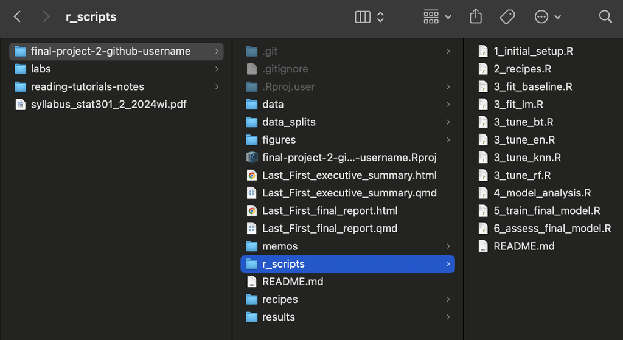

**Important**

Please note this example project structure is a **guideline**. There are other structures/organizations that are perfectly acceptable. However, it must be straight-forward to understand and navigate.

### The Report

This is a report and should read as such, meaning it should be well organized, clearly articulated (good narrative), and flow in a logical manner.

Some basics:

- There should not be sequences of plots or tables without any explanation.
- There should be absolutely no code in your report **— don’t hide it; code should not be visible in any way**.
- There should be no tibbles/data frames or raw R output — should use tables!
- There should be a unique title that is appropriate for your project (“STAT 301-2 Final Project” is not a good title), author, and date.
- Should use heading and sub-headings appropriately.
- Should include a link to project’s GitHub repo.
- Cannot use names of variables, names of scripts, or names of function.
- All figures and tables should be properly labeled and referenced **—must make use of quarto cross-referencing)**.

Your report will likely contain some variation of the section headers listed below. The names can be modified as long as it is fitting for the section. Where appropriate, subsections should be used.

- Introduction
- Data Overview
- Methods
- Model Building & Selection
- Final Model Analysis
- Conclusion
- Comment on Generative AI Use
- References — if needed
- Appendix: technical info — if needed
- Appendix: EDA — if needed
- Appendix: extras — if needed

To some extent the sections should contain, but not limited to the following information.

#### Introduction

Introduce your problem(s)/objective(s). Discuss why you are trying to predict this variable (motivation). Why is this useful? Describe the data source(s) you will use to build a predictive model. If you are obtaining information from websites you should site those in your **References**.

#### Data Overview

At minimum the response variable should be explored and analyzed in detail. Along with an inspection of the data for missingness and severe class imbalance of categorical data. The previous analyses should be conducted on the entire dataset.

Further exploration such as exploring relationships and transformations should be conducted on either a standalone dataset used only for an EDA or some portion of the training dataset from the initial split (can put it back into the training set when building models). Data from the final testing dataset (performance dataset) should not be used for this. This is a key step in feature engineering. A thorough **Exploratory Data Analysis** might be called for, especially if the data is completely new to you, but make sure it is not completed on the entire dataset! Such an EDA could be put in an appendix and only a short summary could be discussed in this section.

#### Methods

Should cover the data splitting procedure and clearly identify what type of prediction problem it is. State and **describe** the model types you will be fitting. Describe any parameters that will be tuned. Describe what recipes will be used. Describe the resampling technique used. In some cases an extended discussion about recipe variations might be useful. Especially if students are using recipe variation to try and explore the predictive importance of certain variables. Explain the metric that will be used to compare and ultimately used to select a final model. Might be helpful to use subsections for data splitting, model descriptions, recipes, etc.

#### Model Building & Selection Results

Should reiterate the metric that will be used to compare models and determine which will be the final/winning model. Include a table of the best performing model results. Review and analysis of tuning parameters should happen here – a column for this in your results table would be nice. Should further tuning be explored? Or how should tuning be adjusted when fitting data like this in the future. This would be a good section to describe what the best parameters were for **each** model type. Could include a discussion comparing any systematic differences in performance between model types or recipes. If variations in recipes were used to explore predictive importance of certain variables, then it should be discussed here. The section will likely end with the selection of the final/winning model (provide your reasoning). Was it surprising or not surprising that this particular model won? Explain.

#### Final Model Analysis

This is where you fit your final/winning model to the testing data. Assess the final model’s performance with at least the metric used to determine the winning model, but it is also advisable to use other performance metrics (especially ones that might be easier to communicate/understand). Should include an exploration of predictions vs the true values (graph) or a confusion matrix (table). Remember to consider the scale of your outcome variable at this time — did you transform the target variable? If a transformation was used, then you should consider conducting analyses on both the original and transformed scale of the target variable. Is the model any good? It might be the best of the models you tried, but does the effort of building a predictive model really pay off — is it that much better than a baseline/null model? Were there any features of the model you selected that make it the best (e.g. fits nonlinearity well)?

#### Conclusion

State any conclusions or discoveries/insights. This is a great place for future work, new research questions, and next steps.

#### References

Any references used should be sited here. This includes but is not limited to where you got your data. There is no “formal” reference guideline but we recommend APA format. Example: Lastname, F. M. (Year, Month Date). *Title of page*. Site name. URL

#### Comment on Generative AI Use

A short section that clearly state whether generative AI tools where used or not to complete any of the work on the final project. If it was used, then the AI tool(s) should be clearly identified (what tool was used) and a desctiption of how they were used should be included (for example, help to write code, help to write, etc.). Describing general details on how the tool(s) where used would also be useful (think describing your basic workflow).

#### Appendix: EDA — if needed

A place to place a more thorough EDA, if needed. This should not include any data from the testing dataset! This should help explain your featured engineered recipe. If you don’t need this section you should ask yourself if your feature engineered recipe is complex enough.

#### Appendix: Tuning Parameter Analysis — if needed

A place to put the autoplots of tuning parameters from each of the models (minimum of 8 tuned models). You should explain the findings from each plot.

#### Appendix: technical info — if needed

A place to share complex and important technical steps that may highly impact explorations, but the details are too technical to share in main body of the report.

#### Appendix: extras — if needed

Add as many appendices as needed.

### Executive Summary

An executive summary should summarize the key points of the report. It should restate the purpose of the report, highlight the major results, and summarize any conclusions. This report should be concise and clearly written. If you are unsure how to [write an Executive Summary](https://writingcenter.uagc.edu/writing-executive-summary#:~:text=An%20executive%20summary%20should%20summarize,or%20recommendations%20from%20the%20report.) there are a lot of resources on the internet! Consider visiting the [writing center](https://www.writing.northwestern.edu/) if you need help.

**Important**

Include the **Comment on Generative AI Use** in the executive summary.

### Rubric

| Pre-Project | 0😱 | 1 😨 | 2😦 | 3😕 | 4🙂 | 5🤩 |
| --- | --- | --- | --- | --- | --- | --- |
| Progress Memo 1 |  |  |  |  |  | All requirements met |
| Progress Memo 2 |  |  |  |  |  | All requirements met |

[output not shown]

[output not shown]

| Executive Summary | 0😱 | 2 😨 | 4😦 | 6 😕 | 8🙂 | 10 🤩 |
| --- | --- | --- | --- | --- | --- | --- |
| Executive Summary Report |  |  |  |  |  | Clearly and concisely explains the purpose of the report and highlights the major results and conclusions. You could present this to your boss and they would be able to understand your results. |

| Total |  |  |  |  |  | /100 |
| --- | --- | --- | --- | --- | --- | --- |